# Basic Chub Reports

*This report is generated using data from all chubs produced within a 2 week window of 10/15/2019 to 10/29/2019.*

**Objectives**

1. Keep 99% of what we make (dashed blue lines) within our spec limits (solid red lines).
2. Keep our average (middle blue line) as close to the target (center red line) as possible.
3. Minimize the amount of rework (everything left of the green line).

## **1 LB Chub**

| Lower 99% | Lower Spec Limit | Average | Upper Spec Limit | Upper 99% |
| --- | --- | --- | --- | --- |
| 0.9 | 0.94 | 0.996 | 1.05 | 1.09 |

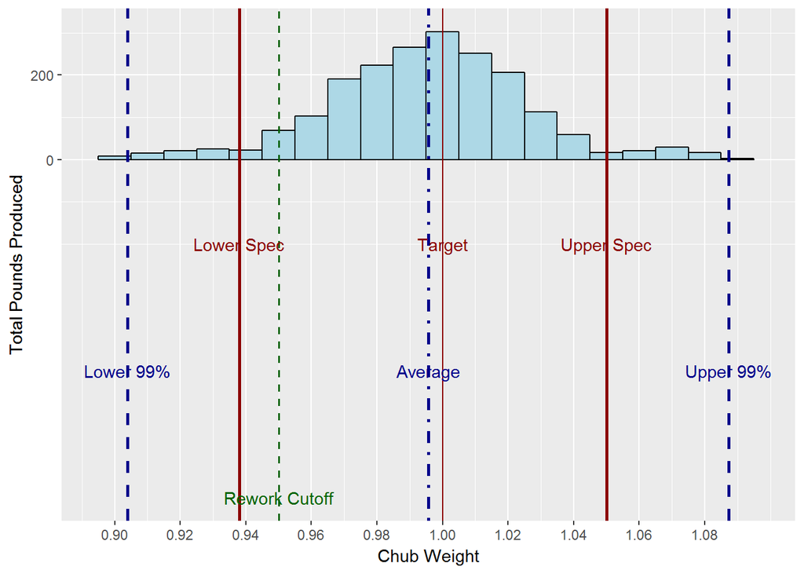

**Recommendations**

Variation in chub weights must be reduced. You cannot consistently produce chubs that are above USDA minimum weight requirement AND below Stone Meats maximum weight requirement.

Shifting chub weight average not recommended until variation is reduced.

**Rework & Loss**

Total Produced: 5881 lbs

Total rework: 333 lbs (5.7%)

Loss: -26 lbs (-0.44%)

## **3 LB Chub**

| Lower 99% | Lower Spec Limit | Average | Upper Spec Limit | Upper 99% |
| --- | --- | --- | --- | --- |
| 2.91 | 2.94 | 3.02 | 3.15 | 3.13 |

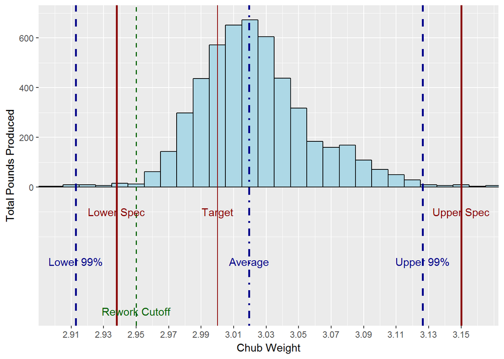

**Recommendations**

Variation in chub weights must be reduced. You cannot consistently produce chubs that are above USDA minimum weight requirement AND below Stone Meats maximum weight requirement.

Shifting chub weight average not recommended until variation is reduced.

**Rework & Loss**

Total Produced: 5061 lbs

Total rework: 71 lbs (1.4%)

Loss: 33 lbs (0.65%)

## **5 LB Chub**

| Lower 99% | Lower Spec Limit | Average | Upper Spec Limit | Upper 99% |
| --- | --- | --- | --- | --- |
| 4.8 | 4.91 | 5.006 | 5.25 | 5.21 |

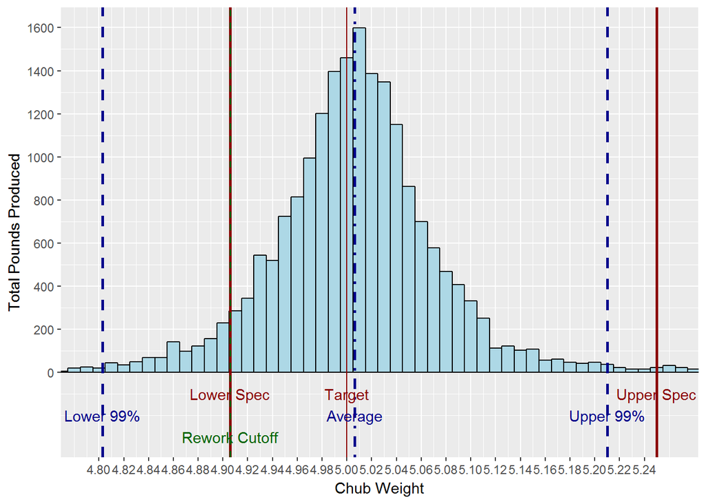

**Recommendations**

Variation in chub weights must be reduced. You cannot consistently produce chubs that are above USDA minimum weight requirement AND below Stone Meats maximum weight requirement.

Shifting chub weight average not recommended until variation is reduced.

**Rework & Loss**

Total Produced: 19379.4 lbs

Total rework: 1232 lbs (6.4%)

Loss: 24 lbs (0.12%)